# The Gender Wage Gap Across Education Levels

Clara Yoder

2026-04-28

## Introduction

This project studies the gender wage gap by education levels using data from the American Community Survey. I compare average wages across gender and education groups and estimate a regression model, including an interaction between gender and education. The goal is to determine whether higher education reduces or increases the wage gap.

I hypothesize women to earn lower wages than men, even when controlling for education levels. Understanding gender wage disparities is important because it can be used to assess labor market equity, to inform public policy, and to detect whether wage gaps persist even after controlling for differences in human capital such as education.

The wage gaps associated with education are important because higher education is often used to equalize opportunities, so gaps at higher degrees indicate deeper structural inequalities that education alone cannot resolve.

# Data and Methods

This analysis uses a cross sectional observational research design, since all variables are measured at one point in time.

## Loading the IMPUMS Data

I began by loading the wage and demographic data from the American Community Survey, which includes information on income, gender and education.

```
## # A tibble: 6 × 15
##    YEAR SAMPLE        SERIAL CBSERIAL  HHWT CLUSTER GQ      PERNUM PERWT SEX
##   <int> <int+lbl>      <dbl>    <dbl> <dbl>   <dbl> <int+l>  <dbl> <dbl> <int+l>
## 1  2024 202401 [2024… 9.06e5  2.02e12     9 2.02e12 3 [Gro…      1     9 2 [Fem…
## 2  2024 202401 [2024… 1.49e6  2.02e12    51 2.02e12 1 [Hou…      2    97 1 [Mal…
## 3  2024 202401 [2024… 6.15e4  2.02e12   111 2.02e12 1 [Hou…      2    55 1 [Mal…
## 4  2024 202401 [2024… 1.46e6  2.02e12    68 2.02e12 1 [Hou…      2    76 1 [Mal…
## 5  2024 202401 [2024… 1.25e6  2.02e12    99 2.02e12 1 [Hou…      2   101 2 [Fem…
## 6  2024 202401 [2024… 1.51e6  2.02e12    23 2.02e12 1 [Hou…      1    24 1 [Mal…
## # ℹ 5 more variables: AGE <int+lbl>, EDUC <int+lbl>, EDUCD <int+lbl>,
## #   UHRSWORK <int+lbl>, INCWAGE <dbl+lbl>
```

```
##  chr "gender_wage_data_small.rds"
```

## Raw Wage Differences by Gender

Before running any official models, I looked at the simple differences of wages between men and women to get an idea of the gender gap.

```
## # A tibble: 2 × 2
##   SEX        mean_wage
##   <int+lbl>      <dbl>
## 1 1 [Male]     201660.
## 2 2 [Female]   182563.
```

## Distribution of Annual Wages

This plot represents the distribution of the annual salary and displays a simplistic representation of the dependent variable without dividing it according to gender or education.

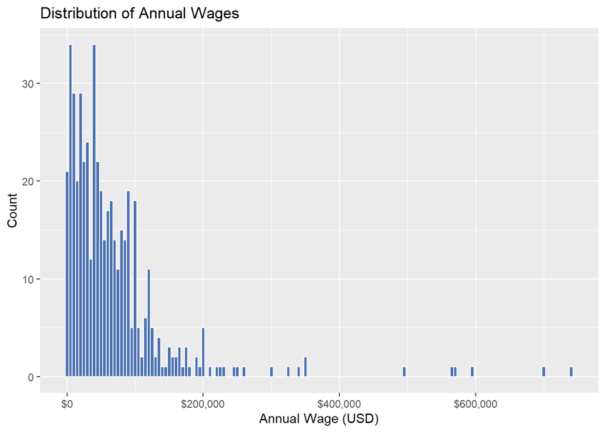

## Data Cleaning and Preparing Variables

I transformed the values to numeric and factor types so that they can be appropriately used in the calculations and regression models.

If the coefficient on the Female variable is negative and statistically significant (p< 0.05), this supports the hypothesis of a gender wage gap. If it is not statistically significant, the data does not provide evidence of a wage gap.

# Descriptive Results

## Visualizing Gender Differences in Wages

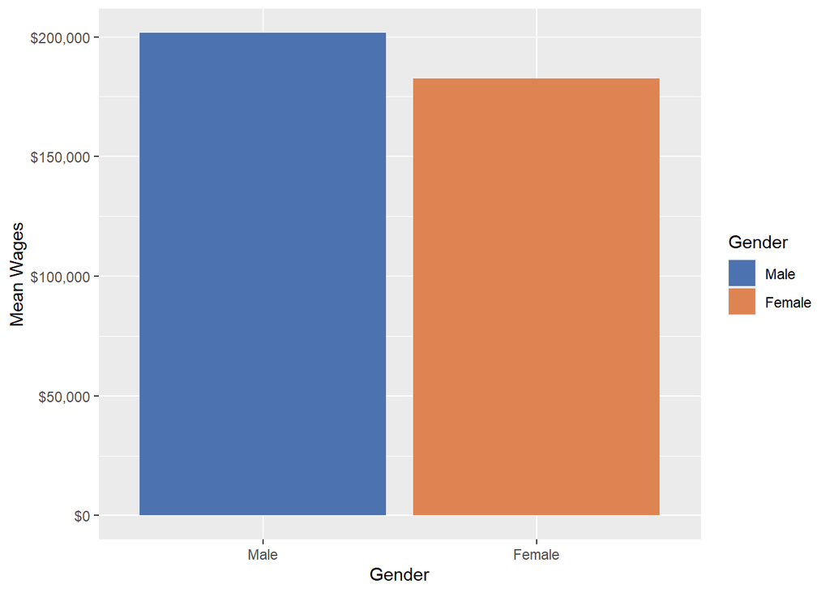

## Modifying Education Variable

## Creating Education Groups

The raw data on education codes are very detailed so I grouped them into broader categories to make the results easier to understand.

## Visualization

This plot shows that the average wages for men and women at each education level. It provides a overview before the regression model. This helps shown the overall pattern in the data before using the regression model.

Mean Wage by Education Level and Gender

| educ_group | SEX | mean_wage |
| --- | --- | --- |
| Less than High School | Male | 50187.78 |
| Less than High School | Female | 27213.64 |
| Some College | Male | 41909.76 |
| Some College | Female | 41210.61 |
| Bachelor’s | Male | 117799.66 |
| Bachelor’s | Female | 71651.52 |
| Graduate Degree | Male | 141741.18 |
| Graduate Degree | Female | 99843.24 |

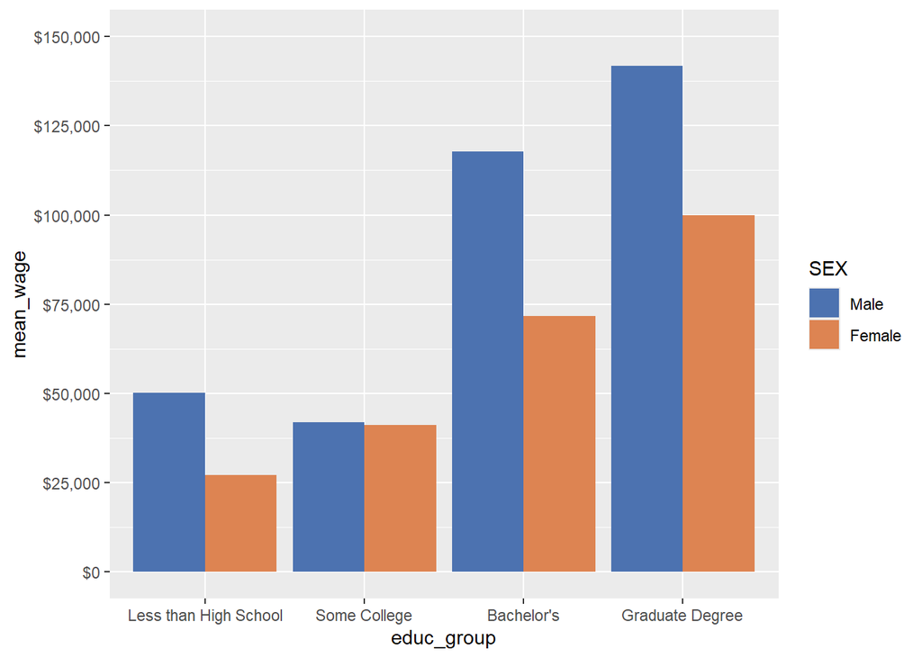

```
## <ggplot2::labels> List of 4
##  $ x    : chr "Education Level"
##  $ y    : chr "Mean Annual Wage"
##  $ fill : chr "Gender"
##  $ title: chr "Mean Wage by Education Level and Gender"
```

This plot shows that women earn less than men at every level of education in the raw data. However, these differences do not account for other factors, so a regression is needed to test if the gap remains after controlling for education.

# Regression Model

## Regression Output

The regression model allows me to estimate how the gender wage gap changes across education levels by including an interaction between gender and education.

Regression Results with Coefficients, Standard Errors, and p-values

| term | estimate | std.error | statistic | p.value |
| --- | --- | --- | --- | --- |
| (Intercept) | 50187.778 | 19559.37 | 2.566 | 0.011 |
| SEXFemale | -22974.141 | 26373.84 | -0.871 | 0.384 |
| educ_groupSome College | -8278.022 | 21599.71 | -0.383 | 0.702 |
| educ_groupBachelor’s | 67611.877 | 22389.66 | 3.020 | 0.003 |
| educ_groupGraduate Degree | 91553.399 | 24188.95 | 3.785 | 0.000 |
| SEXFemale:educ_groupSome College | 22274.991 | 29730.37 | 0.749 | 0.454 |
| SEXFemale:educ_groupBachelor’s | -23173.999 | 30309.15 | -0.765 | 0.445 |
| SEXFemale:educ_groupGraduate Degree | -18923.792 | 32927.66 | -0.575 | 0.566 |

## Additional Regression with Age as a Control Variable

Regression Results with Gender, Education, Interaction, and Age Control

| term | estimate | std.error | statistic | p.value |
| --- | --- | --- | --- | --- |
| (Intercept) | 5940.754 | 22571.741 | 0.263 | 0.793 |
| SEXFemale | -18271.686 | 25958.333 | -0.704 | 0.482 |
| educ_groupSome College | -6292.245 | 21241.123 | -0.296 | 0.767 |
| educ_groupBachelor’s | 68288.450 | 22011.840 | 3.102 | 0.002 |
| educ_groupGraduate Degree | 87854.019 | 23800.490 | 3.691 | 0.000 |
| AGE | 1035.691 | 276.701 | 3.743 | 0.000 |
| SEXFemale:educ_groupSome College | 14200.607 | 29307.189 | 0.485 | 0.628 |
| SEXFemale:educ_groupBachelor’s | -28495.488 | 29830.583 | -0.955 | 0.340 |
| SEXFemale:educ_groupGraduate Degree | -22873.766 | 32388.111 | -0.706 | 0.480 |

## Regression Analysis

This regression, considers whether the gender wage gap varies across different levels of education using an interaction variable between the two. The baseline in this case is men with less than high school education, and then this baseline is adjusted using coefficients for education, gender and the interaction variables.

Even though the descriptive results show that women earn less than men at every level of education, once education is included, the regression tells a different story. The main coefficient for Female is negative (–22,974), but is not statistically significant (p = 0.384). This means that when the categories of education are accounted for, there is no statistically significant proof that women earn less than men.

The education coefficients for Bachelor’s and Graduate Degree are statistically significant implying that wages increase tremendously for men as their education level rise. However, none of the gender–education interactions is statistically significant. This means that there are no clear differences in wages that accrue from education between males and females in the model.

To see if age helps to explain any of these patterns, I also ran an additional regression that adds age as a control variable. As expected, age is related to wages, since older workers generally have more experience. However, including age does not meaningfully change the gender coefficient or any of the gender education interaction terms. The female coefficient remains negative and statistically insignificant, and the interaction terms remain insignificant. Overall, this suggests that age differences between men and women do not explain the wage patterns that are observed in the main model.

Education specific wage gaps matter because we usually expect higher education to level the playing field, so to see gaps even at advanced degree levels suggests deep inequalities.

Point estimates also show that women continue to earn less than men at most levels of education, though these differences are not statistically significant. Because of that, these results are interpreted as patterns in the sample and not as factual evidence that the gender wage gap either widens or narrows with education.

Overall, the regression does not confirm that gender wage gap changes in a systematic way across the levels of education after the sampling variability is accounted for.

## Conclusion

In general, these findings can be considered a descriptive picture of relationships, as no causality is established through the regression, because it does not take into account a number of factors such as job type, experience, number of hours worked, industry, etc. Without controlling for them, we can assume neither that the relationship between education and gender wage difference is causal, or that education causes the change in one way or another. We cannot prove whether there is causality here, but we see some kind of dependency.

Based on the regression results, my hypothesis is not statistically supported, even though the descriptive patterns in the data still align with it.

Despite the positive outcome, it needs to be taken into account that the data used may have been inaccurate due to several reasons including the fact that the levels of education are too broad, income is skewed, and the dataset does not include key variables like job type, experience or part time status.

With more detailed data, the analysis could better isolate the gender wage gap and provide stronger evidence about how it changes with education.

## Policy Implications

Even though the results from this regression were not statistically significant, the descriptive patterns still point to persistent gender differences in wages across education levels.

If these patterns reflect labor market trends, policies such as pay transparency laws, standardized salary bands or targeted equity initiatives in high earning professions could help reduce the unexplained wage disparities among gender. More detailed data would allow policymakers to better understand where interventions are most needed to shorten this gap.

## Takeaway

Overall, this project highlights how descriptive patterns can suggest meaningful wage differences even when statistical evidence is limited, highlighting the importance of specific data for understanding gender inequality.

```r
knitr::opts_chunk$set(echo = TRUE, message = FALSE, warning = FALSE)
library(tidyverse)
library(haven)
gender <- readRDS("data/gender_wage_data_small.rds")
head(gender)

str("gender_wage_data_small.rds")
library(tidyverse)
library(haven)

gender <- gender |>
  mutate(
    INCWAGE = as.numeric(zap_labels(INCWAGE))
  )
gender |>
  group_by(SEX) |>
  summarize(
    mean_wage = mean(as.numeric(INCWAGE), na.rm = TRUE)
  )
gender_clean <- gender |>
  filter(INCWAGE > 0, INCWAGE < 999999)

ggplot(gender_clean, aes(x = INCWAGE)) +
  geom_histogram(binwidth = 5000, fill = "#4C72B0", color = "white") +
  scale_x_continuous(labels = scales::dollar) +
  labs(
    title = "Distribution of Annual Wages",
    x = "Annual Wage (USD)",
    y = "Count"
  )
library(haven)
library(dplyr)

gender <- gender |>
  mutate(
    SEX = as.numeric(zap_labels(SEX)),
    INCWAGE = as.numeric(zap_labels(INCWAGE)),
    SEX = factor(SEX, levels = c(1, 2), labels = c("Male", "Female"))
  )
gender_summary <- gender |>
  group_by(SEX) |>
  summarize(
    mean_wage = mean(INCWAGE, na.rm = TRUE)
  )
library(scales)
ggplot(gender_summary, aes(x = SEX, y = mean_wage, fill = SEX)) +
  geom_col() +
  scale_fill_manual(values = c("Male" = "#4C72B0", "Female" = "#DD8452"))+
  scale_y_continuous(labels = dollar)+
  labs(
    x= "Gender",
    y= "Mean Wages",
    fill= "Gender"
  )

gender <- gender |>
  mutate(
    EDUCD = as.numeric(haven:: zap_labels(EDUCD))
  )
gender <- gender |>
  mutate(
    educ_group = case_when(
      EDUCD < 62 ~ "Less than High School",
      EDUCD == 62 ~ "High School",
      EDUCD %in% c(63, 64, 65) ~ "Some College",
      EDUCD == 101 ~ "Bachelor's",
      EDUCD > 101 ~ "Graduate Degree",
      TRUE ~ NA_character_
    )
  )

library(dplyr)
library(tidyr)
library(ggplot2)


gender_clean <- gender |>
  filter(INCWAGE > 0, INCWAGE < 999999) |>
  mutate(
    educ_group = fct_relevel(
      educ_group,
      "Less than High School",
      "High School",
      "Some College",
      "Bachelor's",
      "Graduate Degree"
    )
  )


education_summary <- gender_clean |>

  filter(!is.na(educ_group)) |>
  group_by(educ_group, SEX) |>
  summarize(
    mean_wage = mean(INCWAGE, na.rm = TRUE),
    .groups = "drop"
  ) |>

  complete(
  educ_group,
  SEX,
  fill = list(mean_wage = 0)
)
  knitr::kable(education_summary, caption = "Mean Wage by Education Level and Gender")

ggplot(education_summary, aes(x = educ_group, y = mean_wage, fill = SEX)) +
  geom_col(position = "dodge") +
  scale_fill_manual(values = c("Male" = "#4C72B0", "Female" = "#DD8452")) +

  coord_cartesian(ylim = c(0, 150000)) +
  scale_y_continuous(
    breaks = seq(0, 150000, 25000),
    labels = dollar_format(accuracy = 1)
  )
  labs(
    title = "Mean Wage by Education Level and Gender",
    x = "Education Level",
    y = "Mean Annual Wage",
    fill = "Gender"

)

library(broom)
tidy(lm(INCWAGE ~ SEX * educ_group, data = gender_clean)) |>
  knitr::kable(
    digits = 3,
    caption = "Regression Results with Coefficients, Standard Errors, and p-values"
  )

additional_model <- lm(INCWAGE ~ SEX * educ_group + AGE, data = gender_clean)

broom::tidy(additional_model) |>
  knitr::kable(
    digits = 3,
    caption = "Regression Results with Gender, Education, Interaction, and Age Control"
  )
```